# Instructions

## Part I, Due Friday 2/23

In this assignment you will use your own text file of at least 100 words to generate some lines of predictive text.

1. **Read [Section 5.1 of your text](https://app.perusall.com/courses/math-352-01-24-sp/_/dashboard/assignments/rey2TZNhubAqdkgcT) posted on Perusall for the theoretical background on Markov Chains.**  
   You can also view the notes from class on [Dynamical Systems and Markov Chains here.](https://drive.google.com/file/d/10ruxIntPYd1zf2dldrPiqk_QZFAyKwky/view?usp=sharing)
2. **Chose some text file of your own containing at least 100 words. Run the code below to upload your file.** *Carriage returns seem to be a problem, so try to make sure your txt file is one single line of text.*

```python
import numpy as np

from google.colab import files
uploaded = files.upload()
```

Upload widget is only available when the cell has been executed in the current browser session. Please rerun this cell to enable.

```
Saving bee_movie_script.txt to bee_movie_script.txt
```

**In the code below, replace MidSummerText.txt with the name of your text file. Read over the code below and make sure you understand what it does.** In particular, the python command

```
dict()
```

creates a dictionary. For more information see https://docs.python.org/3/tutorial/datastructures.html#dictionaries

```python
textfile= open('bee_movie_script.txt', 'r')
text=textfile.read()
text = text.replace('\n',' ')

wordlist = text.split(" ")
wordset= set(wordlist)

#creating a word dictionary that assigns each word in the document a number i.  Incudes repeats
numberdictionary = dict()
worddictionary = dict()
for i, word in enumerate(wordset):
  numberdictionary[word]= i
  worddictionary[i]= word

#for each word in the document, the following code creates a dictionary of words following that word and the number of times each word follow directly after the given word.
frequencies= dict()
for i in wordset:
  frequencies[i]= dict()
for j in range(len(wordlist)-1):
  if wordlist[j+1] in frequencies[wordlist[j]]:
    frequencies[wordlist[j]][wordlist[j+1]]+=1
  else:
    frequencies[wordlist[j]][wordlist[j+1]]=1

#Using the number of times a certain word follows a given word to create the Markov transition matrix
transitionmatrix =np.zeros((len(wordset),len(wordset)))
for i in frequencies:
  ptotal = sum(frequencies[i].values())
  for j in frequencies[i]:
    transitionmatrix[numberdictionary[j]][numberdictionary[i]]=frequencies[i][j]/ptotal #the probability word j follows word i
```

## Part II: Due Monday 2/26

3. **Read over the code below and make sure you understand what it does.**

```python
def predict(word, length):
  string = word
  for i in range(0,length-1):
    probability = transitionmatrix[:, numberdictionary[word]]
    nextwordindex =np.random.choice(range(0, len(wordset)), p= probability)
    word = worddictionary[nextwordindex]
    string = string + " " + word
  return(string)
```

```python
predict('honey', 75)
```

```
"honey production! Mission abort. Aborting pollination and there's a fold-out brochure. My sweater is JFK control tower, Flight 356. What's going 0900 at a Cinnabon is? It's amazing. Why do we do it? You're crazy! Hello? Benson, got all set to me. - Park. - I'm a life raft exploded. One's bald, one'…
```

4. **Use the predict function to generate generate some lines of predictive text based on your text file. Try different lengths and seed words.**

predict('fly', 50) output: fly at that. You know how much pain? - Yes. No. He's back different. - We throw pillows! OK, Barry. Good friends? - That blew the guest spot on here. - You're busted, box boy! I don't want to them. But you've gotta weave some honey and so what can

predict('bee', 100) output: bee existence. These are you have to the bees! Free the princess, and there's a jar of Natural History keychains? We're us. So long, bee! Thinking bee! Thinking bee! - I could you want. I know what you're on. You taught me against my part of honey. They're striped stem-suckers! All right, your only one bee I've met someone. You think billion-dollar multinational food companies collectively? A little. Special day, graduation. Never thought I'd catch up. Yeah, but I see in New York. Where's the stirrer! - Bees have to the other, he could say that? It felt there are

> b. **In a short paragraph, describe how the process works. How is the code generating the predictive text?**

The code takes the text file and then makes a set of unique words, while also making addtional dictonaries to map each word and number to the other dictionary. The code also ensures that this is done for the other direction in case it needs to go back. The code then makes the "frequencies" dictionary to keep track of how often a word follows another word in the text file. With these elements, the code makes a Markov Matrix and assigns probability values to move one word to another. This comes into play later when the code runs the predict function, which will use a starting word from the user and generate a sequence of words based on what word the user inputted, as well as the length inputted (so if the user inputted 50 for the length, the code would output 50 words). The code is able to output these sequences of words by itteratively choosing the next word based on the probabilities in the generated Markov Matrix from earlier.

ChatGPT and Bard use a similar process (built on a much larger data set than a text file of 100 words), but add a second AI layer to the algorithm designed to improve the results.

5. **The steady-state vector $\vec{q}$ for the transition matrix $P$** is the state vector satisfying the relatioship $$P\vec{q}=\vec{q},$$ or equivalently $$(P-I)\vec{q}=\vec{0}.$$

**Find an approximation of the steady-state vector for your transition matrix from part 2 in the code cell below.** *You can approximate the steady state vector by calculating* $$\vec{r_{i+1}}=P\vec{r_i}$$ and comparing the values. If $\vec{r_{i}}$ is the steady state vector then $\vec{r_{i+1}}$ will equal $\vec{r_i}.$ You can set $\vec{r_0}$ equal to any distribution vector (vector of non-negative values which sum to 1) of length equal to your word list. Calculate $\vec{r_{i+1}}$ until the difference $\vec{r_{i+1}}-\vec{r_i}$ is approximately zero, or in other words when the sum of the absolute value of the components of $\vec{r_{i+1}}-\vec{r_i}$ is sufficiently small.

```python
#Write a short routine to calculate the steady state vector.

def calculate_steady_state(transition_matrix, limit=10**-8, max_iterations=1000):
    # Set up our initial distribution vector
    r_i = np.ones(len(transition_matrix)) / len(transition_matrix)

    for i in range(max_iterations):
        r_next = np.dot(transition_matrix, r_i)

        # Check for convergence
        if np.sum(np.abs(r_next - r_i)) < limit:
            break

        r_i = r_next

    return r_i

# Calculate steady state vector by using transition matrix
steady_state_vector = calculate_steady_state(transitionmatrix)

print(steady_state_vector)
```

```
[9.48772700e-05 9.48907762e-05 2.84650741e-04 ... 9.48734993e-05
 9.48711450e-05 9.48351293e-05]
```

6. **Pick a word from your text that is followed by at least 3 different words. Using your frequencies dictionary or your transition matrix from part 2, draw part of a state diagram starting with this word and including all the words which follow this word and all the words that follow those words.** If this gets out of control you can just indicate that a whole lot of branches are coming from a particular node and not specify all of them. Your diagram will be subgraph of the kinds of state diagrams appearing in Figures 5.1.1 and 5.1.3 in your text. You can leave out arrows with probability 0. Insert the images or your state diagrams in the textbox below.

```python
#for word, following_words in frequencies.items():  This was to help me see all the words that had words that followed them. The terminal got HUGE, so I just made this but particular for one word at a time
    #if len(following_words) >= 3:
        #Help see what words follow others
        #print(f"Word: {word}, Following Words: {list(following_words.keys())}")

chosen_word = 'take'  # Change this to the word you're interested in
following_words = frequencies[chosen_word]

if len(following_words) >= 3:
    print(f"Words that follow '{chosen_word}': {list(following_words.keys())}")

#This part helps generate probability values for each word
total_following = sum(following_words.values())

for following_word, count in following_words.items():
    probability = count / total_following
    print(f"Probability of '{following_word}' following '{chosen_word}': {probability}")
```

```
Words that follow 'take': ['him', 'a', 'advantage', 'it', 'everything']
Probability of 'him' following 'take': 0.16666666666666666
Probability of 'a' following 'take': 0.3333333333333333
Probability of 'advantage' following 'take': 0.16666666666666666
Probability of 'it' following 'take': 0.16666666666666666
Probability of 'everything' following 'take': 0.16666666666666666
```

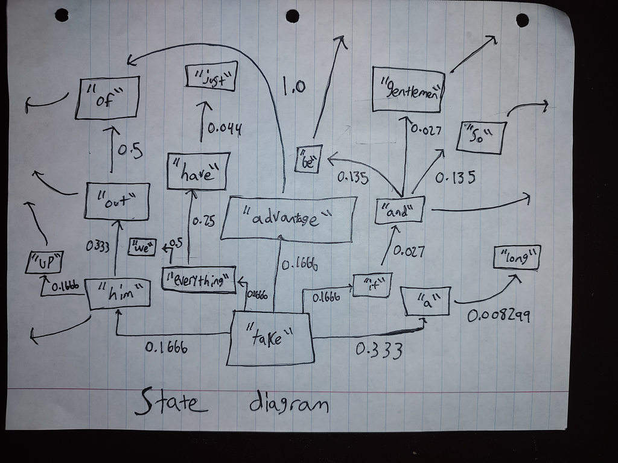

7. **Refelct on the assignment. Write a brief paragraph answering the following:** What did you learn? What parts did your enjoy? Wich parts challenged you the most? And advise for future renditions of the assignment?

Learning how Markov Chains were applicable was definitely eye opening. Seeing how you can you can use it in a context like this really showcased the practical and abstract uses of the concept. We enjoyed seeing how the code mixes up the words of the bee movie script. It was funny for one, and for two, it was actually fascinating to see how well it scrambled up the words and made new sentences. The steady-state vector part definitely presented the most issues. Seeing the code work like it was supposed to was very satisfying. As of now, we can't think of any suggestions on what to change for this assignment. It was enjoable! :)

## Some useful matrix commands

```python
# import numpy
# numpy is great for working with matrix algebras.  It can find the inverse of a matrix and matrix-vector multiplicaiton as shown below.
import numpy as np
v=np.array([[1],[2],[3], [4]]) #v is a column vector
M=np.array([[1, 0, 1, 3], [2, 0, 4, 7], [-1, -3, -3, -4], [-1, -7, 5, -4]]) # M is a 4x4 matrix
Minv=np.linalg.inv(M) #Minv is the inverse of the matrix M
c=np.dot(Minv, v)  # c is the matrix-vector product (Minv)v

print(M)
print(c)
```

```python
# import sympy.  Sympy is great for finding the RREF of a matrix
from sympy import *

M = Matrix([[1, 0, 1, 3], [2, 3, 4, 7], [-1, -3, -3, -4]])

# Use sympy.rref() method
print(M.rref()) #M.rref() returns both the RREF of M and a list of the columns containing pivot 1's
M_rref=M.rref()[0]    # Here I am setting M_rref equal to just the RREF of M, and ignoring the vector of pivot 1 locations.
print("The Row echelon form of matrix M and the pivot columns : {}".format(M_rref))
```

```python
!jupyter nbconvert --to html Predictive_Text.ipynb
```